# A Walk-through of RiboR

Michael Geng, Hakan Ozadam, Can Cenik

## Introduction

[Ribosome profiling](https://www.nature.com/articles/nrg3645) is a sequencing based method to study protein synthesis transcriptome-wide. Actively translating mRNAs are engaged with ribosomes and protein synthesis rates can be approximated by the number of ribosomes that are translating a given mRNA. Ribosome profiling employs an RNase digestion step to recover fragments of RNA protected by ribosomes which are called **Ribosome Protected Footprints (RPFs)**.

Ribosome profiling data analyses involve several quantifications for each transcript. Specifically, the lengths of the RPFs provide valuable biological information (see, for example, [Lareau et al.](https://elifesciences.org/articles/01257) and [Wu et al.](https://www.sciencedirect.com/science/article/pii/S1097276518310633?via%3Dihub)). To facilitate ribosome profiling data analyses as a function of RPF length in a highly efficient manner, we implemented a new data format, called [ribo](https://ribopy.readthedocs.io/en/latest/ribo_file_format.html). Files in ribo format are called **.ribo** files. The associated paper for the .ribo file and its larger ecosystem can be found [here](https://academic.oup.com/bioinformatics/advance-article/doi/10.1093/bioinformatics/btaa028/5701654).

RiboR package is an R interface for .ribo files. The package offers a suite of reading functions for .ribo files, and provides plotting functions that are most often employed in ribosome profiling analyses. Using RiboR, one can import .ribo files into the R environment, read ribosome profiling data into data frames and generate essential plots in a few lines of R code.

This document is structured into several sections. First, we give an overview of the Ribo File format and define transcript regions. Second, we provide instructions and requirements for the installation of RiboR. Third, we describe how to import a .ribo file to R environment and demonstrate essential ribosome profiling data analyses in three sections:

- Length Distribution
- Metagene Analysis
- Region Counts

In the following two sections, we describe some advanced features including renaming transcripts using aliases, accessing .ribo file attributes, and getting region boundaries that define transcript regions.  
In the last section, we explain the three optional types of data, which may exist in a .ribo file.

- Metadata: A .ribo file may contain metadata for each experiment and for the .ribo file itself.
- Coverage: A .ribo file can keep the nucleotide level transcriptome coverage.
- RNA-Seq: A ribosome profiling experiment can be paired with an RNA-Seq experiment to study ribosome occupancy together with transcript abundance.

In the final section, we outline a simple analysis to study translational efficiency.

### .ribo File Format

.ribo files are built on an [HDF5](https://www.hdfgroup.org/solutions/hdf5/) architecture and has a predefined internal structure (Figure 1). For a more detailed explanation of the ribo format, we refer to [readthedocs page of ribo](https://ribopy.readthedocs.io/en/latest/ribo_file_format.html).

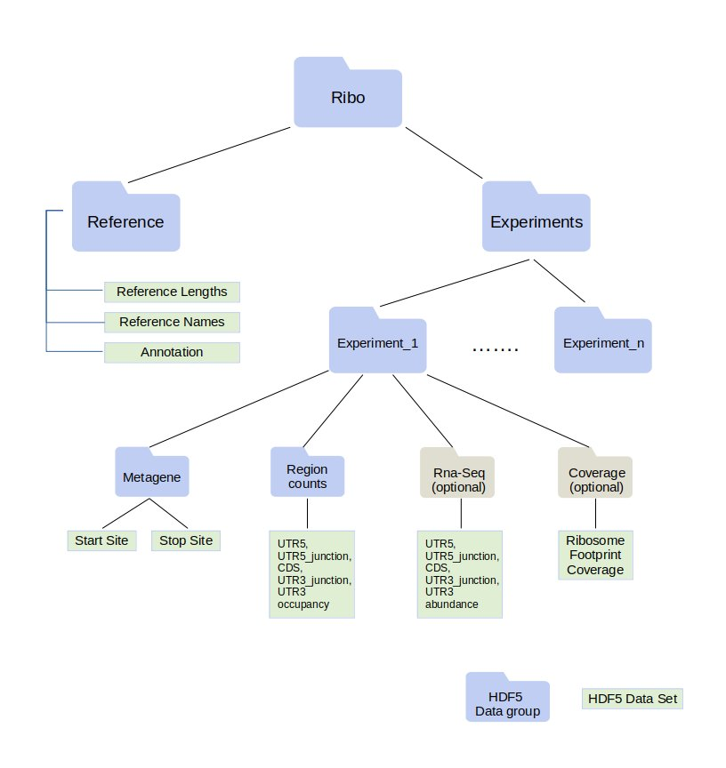

Figure 1: .ribo File Internal Structure

While many features are required in .ribo files, quantification from paired RNA-Seq data and nucleotide-level coverage are optional.

## Installation

### Availability

The source code of RiboR package is available in a [public Github repository](https://github.com/ribosomeprofiling/ribor).

### Bioconductor

RiboR is a [Bioconductor](https://www.bioconductor.org) package. The following R code installs RiboR via Bioconductor.

```r
if (!requireNamespace("BiocManager", quietly = TRUE))
    install.packages("BiocManager")

BiocManager::install("ribor")
```

### Installation From Source Code

RiboR can also be installed directly using the source code. For this, the following are required.

- **R:** RiboR requires **version 3.6 or later**. Previous R versions are known to cause installation and run time problems.
- **Devtools:** Installing the package requires `devtools`, a CRAN package that provides a wide suite of development tools in the R environment.

To install the package, run the following lines of code.

```r
install.packages("devtools")
library("devtools")
install_github("ribosomeprofiling/ribor")
```

For Linux distributions, there are some dependencies, required by devtools. Installation of these dependencies is necessary to install devtools. For Ubuntu-based distributions, the following command installs these dependencies.

```bash
sudo apt-get install libxml2-dev libcurl4-openssl-dev libssl-dev -y
```

## Getting Started

We start with loading the RiboR package.

```r
library(ribor)
```

#### Generating a ribo object

To interact with a .ribo file, it is necessary to create a ribo object that provides a direct handle to the file and displays its various attributes. As an example, we processed publicly available ribosome profiling data (GEO accession number GSE65778) from HEK293 cells using [RiboFlow](https://github.com/ribosomeprofiling/riboflow) pipeline to generate the .ribo file in this document. More precisely, we picked two ribosome profiling experiments coming from untreated HEK293 cells (accession numbers: GSM1606107 and GSM1606108) and two RNA-Seq experiments coming from the same line of untreated cells (accession numbers: GSM1606099 and GSM1606100). Each ribo experiment can be paired with a single RNA-Seq experiment. So we arbitrarily paired the ribosome profiling experiment GSM1606107 with RNA-Seq experiment GSM1606099 and GSM1606108 with GSM1606100, when making the example .ribo file in this document.

```r
#file path to the example ribo file
file.path <- system.file("extdata", "HEK293_ingolia.ribo", package = "ribor")

#generates the 'ribo' class object
original.ribo <- Ribo(file.path, rename = rename_default )
```

**Do not modify the values of the returned ribo object.** Certain values in the `ribo` object’s list are used by later functions, so manually changing these values can alter the correctness of later function calls.

Once the ribo object is created, we can inquire about the contents of the .ribo file.

```r
original.ribo
```

```
#> General File Information:
#>                     info
#>           format version                       1
#>                reference appris_human_24_01_2019
#>          min read length                      28
#>          max read length                      32
#>                left span                      35
#>               right span                      15
#>         transcript count                   19822
#>             has.metadata                    TRUE
#>          metagene radius                      35
#>                has.alias                    TRUE
#>
#> Dataset Information:
#>   experiment total.reads    coverage     rna.seq    metadata
#>   GSM1606107      164536        TRUE        TRUE        TRUE
#>   GSM1606108      215678        TRUE        TRUE        TRUE
```

The above output provides information about the individual experiments that are contained in the given ribo object. In addition, this output displays some of the parameters, that were used in generating the .ribo file, such as left span, right span and metagene radius.

For a detailed explanation of the contents of this output, we refer to the [online documentation of the ribo format](https://ribopy.readthedocs.io/en/latest/ribo_file_format.html).

In what follows, we demonstrate a typical exploration of ribosome profiling data. We start with the length distribution of RPFs.

## Length Distribution

Several experimental decisions including the choice of RNase can have a significant impact on the RPF length distribution. In addition, this information is generally informative about the quality of the ribosome profiling data.

We use the function `plot_length_distribution` to generate the distribution of the reads mapping to a specific region. This function has also a boolean argument called `fraction`. When fraction is `FALSE`, the y-axis displays the total number of reads mapping to the specified region. When fraction is `TRUE`, the y-axis displays the quotient of the same number as above divided by the total number of reads reported in the experiment.

The following code plots the coding region mapping RPF length distribution in the range of 28 to 32 nucleotides.

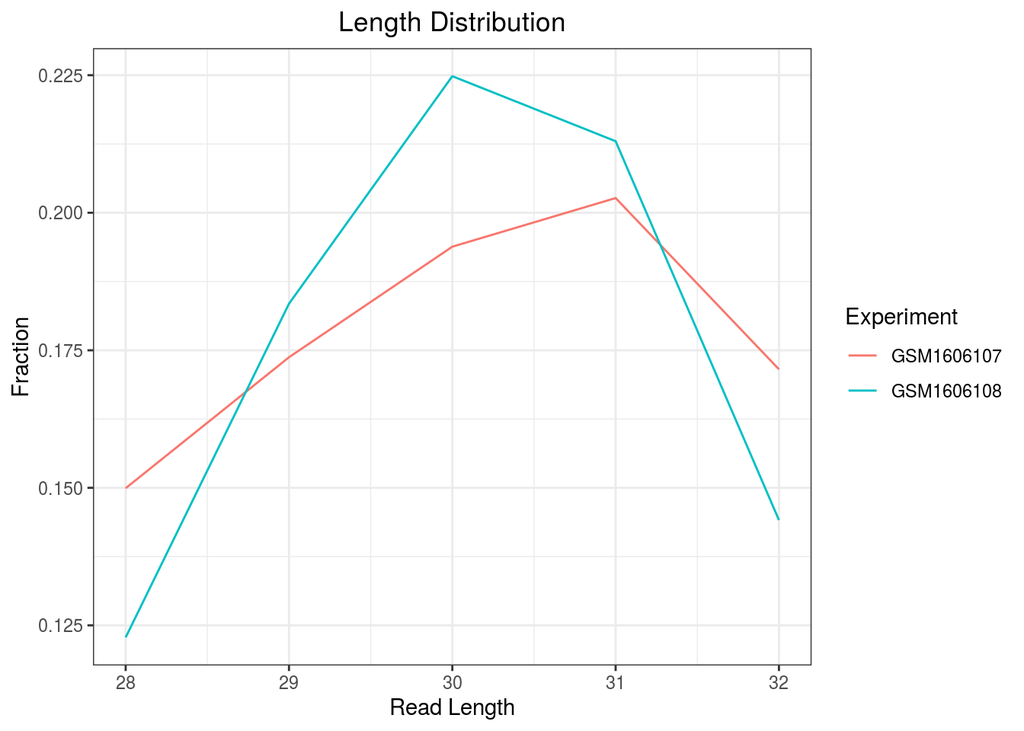

```r
plot_length_distribution(x           = original.ribo,
                         region      = "CDS",
                         range.lower = 28,
                         range.upper = 32,
                         fraction    = TRUE)
```

We can also plot the absolute number of reads instead of the fraction of total reads by changing the argument `fraction = FALSE`.

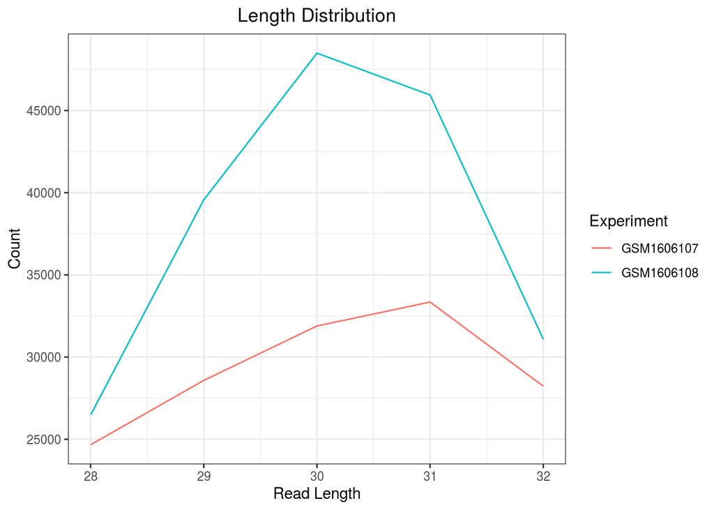

```r
plot_length_distribution(x           = original.ribo,
                         region      = "CDS",
                         range.lower = 28,
                         range.upper = 32,
                         fraction    = FALSE)
```

We can extract the numerical values used to produce the above plot using the function `get_length_distribution` as follows. The parameters of this function will be explained in more detail later in this document.

```r
rc <- get_length_distribution(ribo.object      = original.ribo,
                                   region      = "CDS",
                                   range.lower = 28,
                                   range.upper = 32)
rc
```

```
#> DataFrame with 10 rows and 3 columns
#>    experiment length     count
#>         <Rle>  <Rle> <integer>
#> 1  GSM1606107     28     24669
#> 2  GSM1606107     29     28585
#> 3  GSM1606107     30     31893
#> 4  GSM1606107     31     33347
#> 5  GSM1606107     32     28225
#> 6  GSM1606108     28     26487
#> 7  GSM1606108     29     39570
#> 8  GSM1606108     30     48489
#> 9  GSM1606108     31     45940
#> 10 GSM1606108     32     31087
```

```r
# further DataFrame manipulation and filtering can ensue here
# before calling the plot function

plot_length_distribution(rc, fraction = TRUE)
```

## Metagene Analysis

A common quality control step in ribosome profiling analyses is the inspection of the pileup of sequencing reads with respect to the start and stop site of annotated coding regions. Given that ribosomes are predominantly translating annotated coding regions, these plots are informative about the enrichment at the boundaries of coding regions and also provide information regarding the periodicity of aligned sequencing reads. This type of plot is called a metagene plot as the reads are aggregated around translation start and stop sites across all transcripts.

The parameter “metagene radius” is the number of nucleotides surrounding the start/stop site and hence defines the region of analysis. For each position, read counts are aggregated across transcripts. This cumulative read coverage (y-axis) is plotted as a function of the position relative to the start/stop site (x-axis).

We can identify the metagene radius of .ribo file using the `get_info` function.

```r
get_info(original.ribo)$attributes$metagene_radius
```

```
#> [1] 35
```

We can plot the ribosome occupancy around the start or stop sites using `plot_metagene`. The following code produces the metagene plot at the start site for the experiment GSM1606107. The values on the y-axis are the raw read counts.

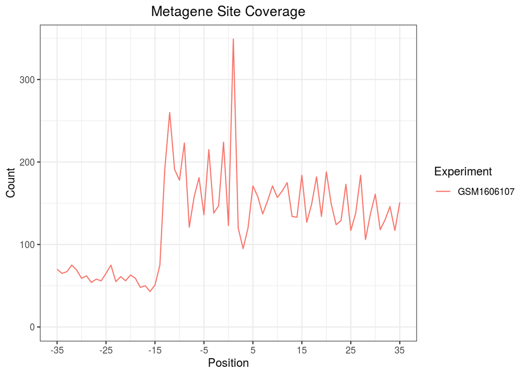

```r
plot_metagene(original.ribo,
              site        = "start",
              experiment  = c("GSM1606107"),
              range.lower = 28,
              range.upper = 32)
```

If we don’t provide a specific value for the the experiments parameter, all available experiments will be plotted. To better compare these experiments, we can normalize the coverage by setting `normalize = TRUE`. In the following example, in addition to these parameters, we set `site = "stop"` to see the stop site coverage.

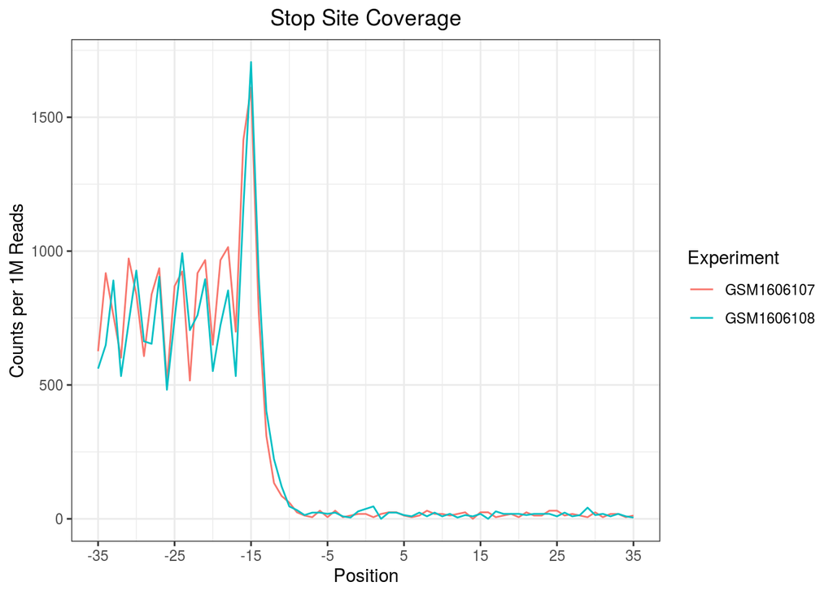

```r
plot_metagene(original.ribo,
              site        = "stop",
              normalize   = TRUE,
              title       = "Stop Site Coverage",
              range.lower = 28,
              range.upper = 32)
```

There are two functions that allow the user to obtain metagene coverage data.

- `get_metagene`
  - This function returns a DataFrame of metagene coverage.
- `get_tidy_metagene`
  - This function returns a tidy DataFrame of metagene coverage. It is a wrapper of the `get_metagene` function, and in order to keep manageable DataFrame dimensions, it will always sum across the transcripts.

When using `length = TRUE` and `transcript = TRUE`, the user will obtain the most concise data corresponding to the sum of reads surrounding the start / stop site across all read lengths and transcripts. As a result, one row of values will be reported for each experiment.

```r
#get the start site across read lengths 28 to 32
meta.start <- get_metagene(ribo.object = original.ribo,
                           site        = "start",
                           range.lower = 28,
                           range.upper = 32,
                           length      = TRUE,
                           transcript  = TRUE)
#only print first ten columns
print(meta.start[ , 1:10])
```

```
#> DataFrame with 2 rows and 10 columns
#>   experiment       -35       -34       -33       -32       -31       -30
#>        <Rle> <numeric> <numeric> <numeric> <numeric> <numeric> <numeric>
#> 1 GSM1606107        70        65        67        75        69        59
#> 2 GSM1606108       102        97        87        82        84        71
#>         -29       -28       -27
#>   <numeric> <numeric> <numeric>
#> 1        62        54        58
#> 2        84        85        74
```

To obtain the tidy version of the above DataFrame,

```r
tidy.meta.start <- get_tidy_metagene(ribo.object = original.ribo,
                                     site        = "start",
                                     range.lower = 28,
                                     range.upper = 32,
                                     length      = TRUE)
head(tidy.meta.start, 2)
```

```
#> DataFrame with 2 rows and 3 columns
#>   experiment position     count
#>        <Rle>    <Rle> <numeric>
#> 1 GSM1606107      -35        70
#> 2 GSM1606108      -35       102
```

To maintain the counts at each individual read length summed across transcripts, use `length = FALSE` and `transcript = TRUE`. If the metagene data of a single read length, say 30, is needed, set `range.lower` and `range.upper` to 30. By default, data retrieval functions return data from all available experiments. To obtain data from a particular subset of experiments, provide a list of experiment names in the `experiments` parameter.

```r
meta.start <- get_metagene(ribo.object = original.ribo,
                           site        = "start",
                           range.lower = 30,
                           range.upper = 30,
                           experiment  = c("GSM1606108"),
                           length      = FALSE,
                           transcript  = TRUE)

print(meta.start[, 1:10])
```

```
#> DataFrame with 1 row and 10 columns
#>   experiment length       -35       -34       -33       -32       -31       -30
#>        <Rle>  <Rle> <numeric> <numeric> <numeric> <numeric> <numeric> <numeric>
#> 1 GSM1606108     30        35        24        26        26        24        23
#>         -29       -28
#>   <numeric> <numeric>
#> 1        15        14
```

If we wish to preserve the read counts for individual transcript sum across a range of read lengths, we set `transcript = FALSE` and `length = TRUE`. While it is possible to set `transcript = FALSE` and `length = FALSE`, run times might be slower for this option, and running the function with these options requires a substantial amount of memory.

```r
meta.start <- get_metagene(ribo.object = original.ribo,
                           site        = "start",
                           range.lower = 28,
                           range.upper = 32,
                           length      = TRUE,
                           transcript  = FALSE,
                           alias       = TRUE)

print(meta.start[1:2, 1:10])
```

```
#> DataFrame with 2 rows and 10 columns
#>   experiment transcript       -35       -34       -33       -32       -31
#>        <Rle>   <factor> <numeric> <numeric> <numeric> <numeric> <numeric>
#> 1 GSM1606107  OR4F5-201         0         0         0         0         0
#> 2 GSM1606107 OR4F29-201         0         0         0         0         0
#>         -30       -29       -28
#>   <numeric> <numeric> <numeric>
#> 1         0         0         0
#> 2         0         0         0
```

As we discussed above for read length analysis, we also provide the option to generate metagene plots using the DataFrames returned by `get_metagene`.

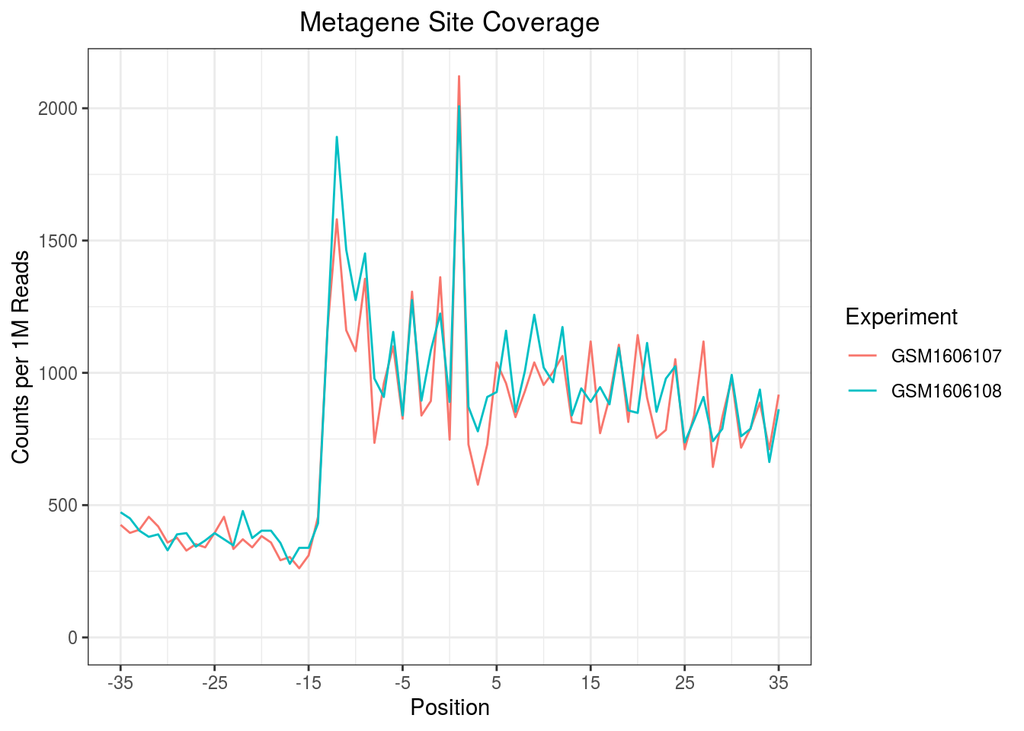

```r
plot_metagene(tidy.meta.start, normalize = TRUE)
```

### A Note on Aggregating the Output

In the above function calls, we used two parameters `length` and `transcript`, which are used, in general, by reading and plotting functions in RiboR. These parameters determine how data is aggregated.

More precisely:

- **length**:
  - If `TRUE`, the counts will be summed up across the given read length interval. Otherwise, if length is `FALSE`, the counts at each individual read length will be included separately in the output.
- **transcript**:
  - If `TRUE`, the counts will be summed up across all the transcripts. Otherwise, if transcript is `FALSE`, the counts at each individual transcript will be reported separately.

## Region Counts

Another important aspect of ribosome profiling data is the number of reads mapping to the different regions of the transcripts, namely, 5’UTR, CDS and 3’UTR. A large number of reads mapping to UTR5 or UTR3 regions might indicate a poor quality ribosome profiling data since ribosomes occupy CDS. Furthermore, the distribution of reads across these regions can be associated with the RNase choice in the experiment. For example in [Miettinen and Bjorklund](https://academic.oup.com/nar/article/43/2/1019/2414322), it was shown that ribosome profiling experiments are dependent on digestion conditions.

Before going into the R functions, we briefly explain how region counts are computed, introduce our naming convention and define the regions used in ribo format.

For each read mapped to the transcriptome, we take the first nucleotide on the 5’ end of the read and determine the corresponding region. After doing this for all reads, the accumulated values give us the region counts.

As mentioned earlier, a messenger RNA transcript is partitioned into three regions: 5’UTR, CDS and 3’UTR. For technical reasons, we rename 5’UTR as UTR5 and 3’UTR as UTR3.

It is well-known that ribosomes pause, or move slower, around start and stop sites. As a result, we observe peaks around start and stop sites in metagene plots. This behavior of ribosome makes it harder to perform certain analyses such as coverage, translation efficiency, periodicity and uniformity analysis with accuracy. To tackle this problem, we introduce two additional regions called **UTR5 junction** and **UTR3 junction**, and modify the definition of the regions UTR5, CDS and UTR3 as shown in Figure 2. This way, we keep regions around start and stop sites separate when doing such analyses.

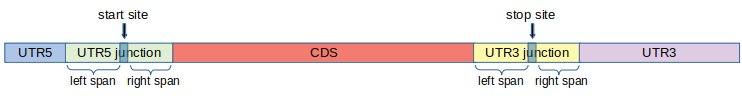

Figure 2: Extended Region Definitions

More precisely, first, we fix two integers: **left span** (**l**) and **right span** (**r**) and define the **junction** regions as follows.

- **UTR5 junction:** This region consists of **l** nucleotides to the left of the **start** site , and **r** nucleotides to the right of the **start** site.
- **UTR3 junction:** This region consists of **l** nucleotides to the left of the **stop** site , and **r** nucleotides to the right of the **stop** site.

Using these junction regions, we re-define the conventional regions as follows.

- **UTR5**: This region is the set of nucleotides between the 5’ end of the transcript and the UTR5 junction.
- **CDS**: This region is the set of nucleotides between the UTR5 junction and UTR3 junction.
- **UTR3**: This region is the set of nucleotides between the UTR3 junction and the 3’ end of the transcript.

Similar to the `get_metagene` function, the `get_region_counts` function has the `transcript` and `length` parameters. As previously mentioned, `transcript` specifies whether or not to sum across the transcripts, and `length` specifies whether or not to sum across the read lengths.

The following code will plot the number of sequencing reads whose 5’ ends map to the UTR5, CDS, and UTR3 as a stacked bar plot. To facilitate comparison between experiments, the percentage of the regions counts are plotted and the percentage of reads mapping to CDS are printed on the plot.

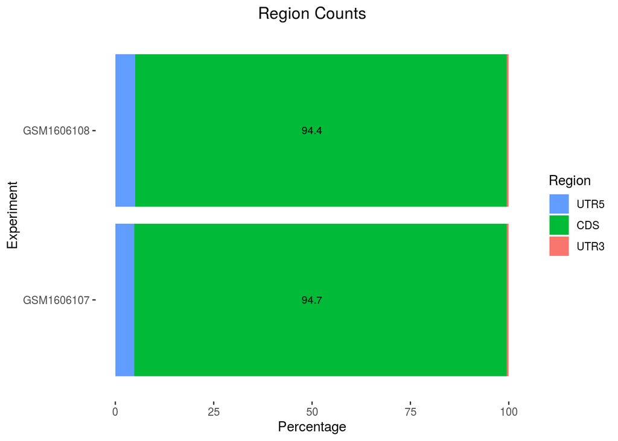

```r
plot_region_counts(x           = original.ribo,
                   range.lower = 28,
                   range.upper = 32)
```

To get the region counts summed across both lengths and transcripts, set `length = TRUE` and `transcript = TRUE`.

```r
rc <- get_region_counts(original.ribo,
                        range.lower = 28,
                        range.upper = 32,
                        length      = TRUE,
                        transcript  = TRUE,
                        region      = c("CDS"))
rc
```

```
#> DataFrame with 2 rows and 3 columns
#>   experiment region     count
#>        <Rle>  <Rle> <numeric>
#> 1 GSM1606107    CDS    146719
#> 2 GSM1606108    CDS    191573
```

When presented with the option of preserving the region counts at each individual read length, it may be preferable to present the transcript names as their shortened aliases.

```r
rc <- get_region_counts(original.ribo,
                        range.lower = 28,
                        range.upper = 32,
                        length      = TRUE,
                        transcript  = FALSE,
                        alias       = TRUE,
                        region      = c("CDS"))
rc
```

```
#> DataFrame with 39644 rows and 4 columns
#>       experiment  transcript region     count
#>            <Rle>    <factor>  <Rle> <integer>
#> 1     GSM1606107   OR4F5-201    CDS         0
#> 2     GSM1606107  OR4F29-201    CDS         0
#> 3     GSM1606107  OR4F16-201    CDS         0
#> 4     GSM1606107  SAMD11-202    CDS         8
#> 5     GSM1606107   NOC2L-201    CDS        88
#> ...          ...         ...    ...       ...
#> 39640 GSM1606108  MT-CO2-201    CDS        28
#> 39641 GSM1606108 MT-ATP8-201    CDS         4
#> 39642 GSM1606108 MT-ATP6-201    CDS        35
#> 39643 GSM1606108 MT-ND4L-201    CDS         2
#> 39644 GSM1606108  MT-ND5-201    CDS        30
```

To get the data in its full form, preserving the information each individual read length and transcript, set `length = FALSE` and `transcript = FALSE`.

```r
rc <- get_region_counts(original.ribo,
                        range.lower = 28,
                        range.upper = 32,
                        length      = FALSE,
                        transcript  = FALSE,
                        alias       = TRUE,
                        region      = c("CDS"))
rc
```

```
#> DataFrame with 198220 rows and 5 columns
#>        experiment  transcript length region     count
#>             <Rle>    <factor>  <Rle>  <Rle> <integer>
#> 1      GSM1606107   OR4F5-201     28    CDS         0
#> 2      GSM1606107  OR4F29-201     28    CDS         0
#> 3      GSM1606107  OR4F16-201     28    CDS         0
#> 4      GSM1606107  SAMD11-202     28    CDS         0
#> 5      GSM1606107   NOC2L-201     28    CDS        22
#> ...           ...         ...    ...    ...       ...
#> 198216 GSM1606108  MT-CO2-201     32    CDS        13
#> 198217 GSM1606108 MT-ATP8-201     32    CDS         2
#> 198218 GSM1606108 MT-ATP6-201     32    CDS        10
#> 198219 GSM1606108 MT-ND4L-201     32    CDS         1
#> 198220 GSM1606108  MT-ND5-201     32    CDS         8
```

By default, the DataFrame output is in a tidy form. If non-tidy data set is desired, then set `tidy = FALSE`.

```r
rc <- get_region_counts(original.ribo,
                        range.lower = 28,
                        range.upper = 32,
                        tidy        = FALSE)
rc
```

```
#> DataFrame with 2 rows and 6 columns
#>   experiment      UTR5     UTR5J       CDS     UTR3J      UTR3
#>        <Rle> <numeric> <numeric> <numeric> <numeric> <numeric>
#> 1 GSM1606107      7487      6244    146719      3280       806
#> 2 GSM1606108     10413      8732    191573      4052       908
```

Also, by default, the counts are not normalized, but there is an option to normalize the region counts. Set `normalize = TRUE` to instead obtain the normalized counts per million reads.

```r
rc <- get_region_counts(original.ribo,
                        range.lower = 28,
                        range.upper = 32,
                        normalize   = TRUE,
                        region      = c("CDS"))
rc
```

```
#> DataFrame with 2 rows and 3 columns
#>   experiment region            count
#>        <Rle>  <Rle>        <numeric>
#> 1 GSM1606107    CDS 891713.667525648
#> 2 GSM1606108    CDS 888236.166878402
```

Similar to the case of metagene and length distribution, the bar plot above can be generated directly from a DataFrame.

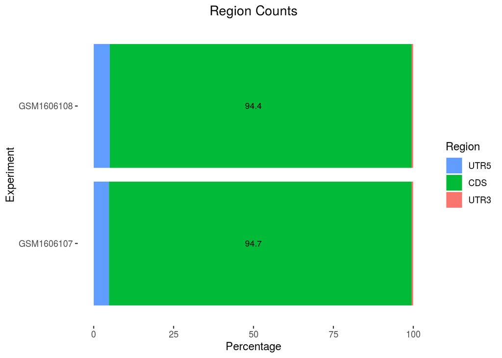

```r
rc.info <- get_region_counts(ribo.object = original.ribo,
                             region      = c("UTR5", "CDS", "UTR3"),
                             range.lower = 28,
                             range.upper = 32)

# further data frame manipulation and filtering can ensue here
# before calling the plot function

plot_region_counts(rc.info)
```

### A Note on the Memory Footprint

In the above function calls, the `compact` parameter is set to TRUE by default, and this parameter is available for all of the offered reading functions. When set to TRUE, it applies Rle (run-length encoding) and factor to several of the columns (notably the columns with repeated values such as experiment, length, and region), and the purpose of this is to reduce the memory footprint of the return values and better accomodate any range of devices using the package.

```r
# default return value with compact = TRUE
compact_rc <- get_region_counts(ribo.object = original.ribo,
                                range.lower = 28,
                                range.upper = 32,
                                length      = TRUE,
                                transcript  = FALSE,
                                compact     = TRUE,
                                alias       = TRUE)
head(compact_rc)
```

```
#> DataFrame with 6 rows and 4 columns
#>   experiment transcript region     count
#>        <Rle>   <factor>  <Rle> <numeric>
#> 1 GSM1606107  OR4F5-201   UTR5         0
#> 2 GSM1606107 OR4F29-201   UTR5         0
#> 3 GSM1606107 OR4F16-201   UTR5         0
#> 4 GSM1606107 SAMD11-202   UTR5         0
#> 5 GSM1606107  NOC2L-201   UTR5         1
#> 6 GSM1606107 KLHL17-201   UTR5         0
```

```r
class(compact_rc)
```

```
#> [1] "DataFrame"
#> attr(,"package")
#> [1] "S4Vectors"
```

```r
object.size(compact_rc)
```

```
#> 3808904 bytes
```

```r
# return value with compact = FALSE
# Note that in this example, it takes up twice as much memory
noncompact_rc <- get_region_counts(ribo.object = original.ribo,
                                   range.lower = 28,
                                   range.upper = 32,
                                   length      = TRUE,
                                   transcript  = FALSE,
                                   compact     = FALSE,
                                   alias       = TRUE)
head(noncompact_rc)
```

```
#>   experiment transcript region count
#> 1 GSM1606107  OR4F5-201   UTR5     0
#> 2 GSM1606107 OR4F29-201   UTR5     0
#> 3 GSM1606107 OR4F16-201   UTR5     0
#> 4 GSM1606107 SAMD11-202   UTR5     0
#> 5 GSM1606107  NOC2L-201   UTR5     1
#> 6 GSM1606107 KLHL17-201   UTR5     0
```

```r
class(noncompact_rc)
```

```
#> [1] "data.frame"
```

```r
object.size(noncompact_rc)
```

```
#> 7608984 bytes
```

If `compact` is FALSE, the called function will return a data.frame instead of a DataFrame, and it will strip the Rle and factor that is applied to several of columns, resulting in a notably larger memory footprint. However, this makes it easier to manipulate and filter the data frame for any downstream analyses, and the data.frame is more readily compatible with other popular packages (i.e. dplyr, tidyr, and ggplot2).

## Advanced Features

### Alias

In the beginning, when we created the ribo object, we used an optional parameter `rename = rename_default`.

```r
original.ribo <- Ribo(file.path, rename = rename_default )
original.ribo
```

```
#> General File Information:
#>                     info
#>           format version                       1
#>                reference appris_human_24_01_2019
#>          min read length                      28
#>          max read length                      32
#>                left span                      35
#>               right span                      15
#>         transcript count                   19822
#>             has.metadata                    TRUE
#>          metagene radius                      35
#>                has.alias                    TRUE
#>
#> Dataset Information:
#>   experiment total.reads    coverage     rna.seq    metadata
#>   GSM1606107      164536        TRUE        TRUE        TRUE
#>   GSM1606108      215678        TRUE        TRUE        TRUE
```

Note that `has.alias` attribute is `TRUE` in the above output. When the ribo object is created with the `rename` parameter, providing alias allows us to rename transcripts, by explicitly setting `alias = TRUE`.

```r
meta.start <- get_metagene(ribo.object = original.ribo,
                           site        = "start",
                           range.lower = 28,
                           range.upper = 32,
                           length      = FALSE,
                           transcript  = FALSE,
                           alias       = TRUE)
meta.start[1:2 , c(1,2,3,38,39,40)]
```

```
#> DataFrame with 2 rows and 6 columns
#>   experiment transcript length        -1         0         1
#>        <Rle>   <factor>  <Rle> <integer> <integer> <integer>
#> 1 GSM1606107  OR4F5-201     28         0         0         0
#> 2 GSM1606107 OR4F29-201     28         0         0         0
```

The transcriptome reference, that we used to generate this .ribo file, is from [GENCODE](https://www.gencodegenes.org). In particular, transcript names in this reference are long for the sake of completeness. For example, they include Ensemble transcript and gene ids in addition to standard gene symbols (HGNC).

```r
head(get_reference_names(original.ribo), 2)
```

```
#> [1] "ENST00000335137.4|ENSG00000186092.6|OTTHUMG00000001094.4|-|OR4F5-201|OR4F5|1054|protein_coding|"
#> [2] "ENST00000426406.3|ENSG00000284733.1|OTTHUMG00000002860.3|OTTHUMT00000007999.3|OR4F29-201|OR4F29|995|protein_coding|"
```

A user might want to work with simplified ids for convenience. To provide this functionality, an optional parameter called `rename` can be provided when initializing a ribo object as shown above.

`rename` parameter can be used in two major ways. The first option is providing a renaming function. This is often a short piece of code that parses the original name and returns a shorter gene, or transcript, name. The RiboR package provides a default renaming function, named `rename_default` for the appris human transcriptome. However, an alternative custom renaming function can also be supplied for example if using a different transcriptome annotation.

The default renaming function extracts the fifth entry in the transcript name, separated by “|”.

```r
rename_default <- function(names){
  return(unlist(strsplit(names, split = "[|]"))[5])
}

rename_default("ENST00000335137.4|ENSG00000186092.6|OTTHUMG00000001094.4|-|OR4F5-201|OR4F5|1054|protein_coding|")
```

```
#> [1] "OR4F5-201"
```

Using the above function, the following code will generate a ribo object and assign an alias to all of the transcripts in a .ribo file.

```r
alias.ribo    <- Ribo(file.path, rename = rename_default)
alias.ribo
```

```
#> General File Information:
#>                     info
#>           format version                       1
#>                reference appris_human_24_01_2019
#>          min read length                      28
#>          max read length                      32
#>                left span                      35
#>               right span                      15
#>         transcript count                   19822
#>             has.metadata                    TRUE
#>          metagene radius                      35
#>                has.alias                    TRUE
#>
#> Dataset Information:
#>   experiment total.reads    coverage     rna.seq    metadata
#>   GSM1606107      164536        TRUE        TRUE        TRUE
#>   GSM1606108      215678        TRUE        TRUE        TRUE
```

Notice that when `rename` is not provided, the `alias` attribute will be false.

```r
noalias.ribo    <- Ribo(file.path)
noalias.ribo
```

```
#> General File Information:
#>                     info
#>           format version                       1
#>                reference appris_human_24_01_2019
#>          min read length                      28
#>          max read length                      32
#>                left span                      35
#>               right span                      15
#>         transcript count                   19822
#>             has.metadata                    TRUE
#>          metagene radius                      35
#>                has.alias                   FALSE
#>
#> Dataset Information:
#>   experiment total.reads    coverage     rna.seq    metadata
#>   GSM1606107      164536        TRUE        TRUE        TRUE
#>   GSM1606108      215678        TRUE        TRUE        TRUE
```

We also provide a second option of supplying a string **vector** containing the alias names directly. The string vector should correspond to the order of reference names in the output of get_reference_names. A subsequent call to `set_aliases` can be used to add aliases to an already existing ribo object. Similar to the above use of the rename parameter, `set_aliases` can be invoked with an appropriate renaming function.

```r
#create a ribo file
alias.ribo    <- Ribo(file.path)

#generate the vector of aliases
aliases <- rename_transcripts(ribo = alias.ribo, rename = rename_default)

#add aliases
alias.ribo <- set_aliases(alias.ribo, aliases)

head(aliases, 3)
```

```
#> [1] "OR4F5-201"  "OR4F29-201" "OR4F16-201"
```

```r
alias.ribo
```

```
#> General File Information:
#>                     info
#>           format version                       1
#>                reference appris_human_24_01_2019
#>          min read length                      28
#>          max read length                      32
#>                left span                      35
#>               right span                      15
#>         transcript count                   19822
#>             has.metadata                    TRUE
#>          metagene radius                      35
#>                has.alias                    TRUE
#>
#> Dataset Information:
#>   experiment total.reads    coverage     rna.seq    metadata
#>   GSM1606107      164536        TRUE        TRUE        TRUE
#>   GSM1606108      215678        TRUE        TRUE        TRUE
```

### File Attributes

If we want a returned list of previously printed attributes, then the function `get_info` will return all of the attributes found in the root of the .ribo file as well as information on each of the experiments. For a detailed explanation, see [the readthedocs page of RiboPy](https://ribopy.readthedocs.io).

Note that this simply returns a named list of many of the ribo object contents. The returned list organizes the information into three separate values, has.metadata, attributes, and experiment.info. This is a more efficient alternative to simply referencing the values in the ribo object since the method reads directly from the .ribo file handle and not the downstream declared ribo object.

```r
#retrieves the experiments
original.info <- get_info(ribo.object = original.ribo)
original.info
```

```
#> $has.metadata
#> [1] TRUE
#>
#> $attributes
#> $attributes$format_version
#> [1] "1.0"
#>
#> $attributes$left_span
#> [1] 35
#>
#> $attributes$length_max
#> [1] 32
#>
#> $attributes$length_min
#> [1] 28
#>
#> $attributes$metagene_radius
#> [1] 35
#>
#> $attributes$reference
#> [1] "appris_human_24_01_2019"
#>
#> $attributes$ribogadgets_version
#> [1] "0.0.1"
#>
#> $attributes$right_span
#> [1] 15
#>
#>
#> $experiment.info
#>   experiment total.reads coverage rna.seq metadata
#> 1 GSM1606107      164536     TRUE    TRUE     TRUE
#> 2 GSM1606108      215678     TRUE    TRUE     TRUE
```

### Region Boundaries

A .ribo file contains the region boundary information. This information can be useful to compare CDS lengths of different transcripts or perform region specific analysis using coverage data.

Some transcripts might have very short regions, compared to left or right span, in their original annotation. In this case, when attempting to set the junction boundaries, the UTR5 and/or UTR3 junctions may take the entirety of any combination of the transcript’s original regions (5’ UTR, CDS, and 3’UTR). Then, UTR5 or UTR3 junctions will take over their nucleotides. Thus, in our modified region definitions, the coordinates of these regions are marked as `NA` and their lengths will be 0.

Region coordinates can be obtained using `get_region_coordinates`.

```r
region_coord <- get_region_coordinates(ribo.object = alias.ribo , alias = TRUE)
head(region_coord, 2)
```

```
#>   transcript UTR5_start UTR5_stop UTR5J_start UTR5J_stop CDS_start CDS_stop
#> 1  OR4F5-201          1         1           2         51        52      916
#> 2 OR4F29-201         NA        NA           1         34        35      920
#>   UTR3J_start UTR3J_stop UTR3_start UTR3_stop
#> 1         917        966        967      1054
#> 2         921        970        971       995
```

Length of regions can be useful to normalize data, say by CDS length, or to compare different transcripts. The function `get_region_lengths` gives region lengths for each transcript.

```r
region_lengths <- get_region_lengths(ribo.object = alias.ribo, alias = TRUE)
head(region_lengths, 2)
```

```
#>   transcript UTR5 UTR5J CDS UTR3J UTR3
#> 1  OR4F5-201    1    50 865    50   88
#> 2 OR4F29-201    0    34 886    50   25
```

### Functionality for Multiple Ribo Files

The functions within RiboR take in a single Ribo object. However, the following helper function, `read_multiple_files`, returns an aggregated data frame, given a named list of Ribo objects and any `RiboR` reader function of interest (`get_metagene`, `get_region_counts`, `get_length_distribution`, `get_coverage`, or `get_rnaseq`) with its associated parameters.

```r
# helper function
read_multiple_files <- function(ribo_list, getter_function, ...) {
  df_list <- lapply(ribo_list, getter_function, ...)
  df_list <- mapply(cbind, df_list, "study" = names(df_list), SIMPLIFY=FALSE)
  df <- dplyr::bind_rows(df_list)
  return (df)
}
```

Note that the `compact` parameter should be set to `FALSE` and that the parameters given will be consistently used across all of the Ribo objects in the given list. This means that lists of Ribo objects containing Ribo files with different properties (e.g. Transcript Aliases, RNA-Seq, Coverage) may need to be filtered for consistency before use.

```r
# create a named Ribo object list of length >= 1
ribo_file_list <- list(original.ribo)
names(ribo_file_list) <- c("GSE65778")

# try out a function
read_multiple_files(ribo_list = ribo_file_list, getter_function = get_region_counts, compact = FALSE, tidy = FALSE)
```

```
#>   experiment  UTR5 UTR5J    CDS UTR3J UTR3    study
#> 1 GSM1606107  7487  6244 146719  3280  806 GSE65778
#> 2 GSM1606108 10413  8732 191573  4052  908 GSE65778
```

As seen in the above output, the names of the Ribo object list allow for a new `study` column in the resulting data frame to allow for easier filtering and processing in downstream analyses.

## Optional Data

Length distribution, metagene coverage and region counts are essential to ribosome profiling data analysis and these data exist in every .ribo file. However, for certain types of analysis, additional data might be required.

For example, periodicity and uniformity analyses require the knowledge of number of reads at each nucleotide position, aka coverage data. Another analysis, called translational efficiency, can be done when transcript abundance information is present. An example of this is seen below in the section, `Sample Analysis`. For these types of analyses, .ribo files offer two types of optional data: coverage data and RNA-Seq data.

It might be helpful to have data explaining how ribosome profiling data is collected, prepared and processed. For this, .ribo files has an additional field, called metadata, to store such data for each experiment and for the .ribo file itself.

Optional data don’t necessarily exist in every .ribo file. Their existence can be checked as follows.

```r
original.ribo
```

```
#> General File Information:
#>                     info
#>           format version                       1
#>                reference appris_human_24_01_2019
#>          min read length                      28
#>          max read length                      32
#>                left span                      35
#>               right span                      15
#>         transcript count                   19822
#>             has.metadata                    TRUE
#>          metagene radius                      35
#>                has.alias                    TRUE
#>
#> Dataset Information:
#>   experiment total.reads    coverage     rna.seq    metadata
#>   GSM1606107      164536        TRUE        TRUE        TRUE
#>   GSM1606108      215678        TRUE        TRUE        TRUE
```

In the above output, we see that both of the experiments have all optional data as the values in the columns ‘coverage’, ‘rna.seq’ and ‘metadata’ are `TRUE`. Also the .ribo file has metadata as the ‘has.metadata’ attribute is TRUE.

### Metadata

A .ribo file can contain metadata for each individual experiment as well as the ribo file itself. If we want to see the metadata of a given experiment, then we can use the `get_metadata` function and specify the experiment of interest.

To view the metadata of the .ribo file, we use the `get_metadata` function.

```r
get_metadata(ribo.object = original.ribo,
             print = TRUE)
#The output is omitted due to its length
```

Metadata can be saved in a variable for later use by setting `print = FALSE`.

```r
info <- capture.output(get_metadata(ribo.object = original.ribo,
                                    print = FALSE))
info
#The output is omitted due to its length
```

To find the experiments that have metadata and subsequently retrieve it from one of the experiments, consider the following.

```r
#obtain a list of experiments with metadata
experiment.info <- get_info(ribo.object = original.ribo)[['experiment.info']]
has.metadata <- experiment.info[experiment.info$metadata == TRUE, "experiment"]
has.metadata
```

```
#> [1] "GSM1606107" "GSM1606108"
```

```r
#store the name of the first experiment with metadata and gets its metadata
experiment <- has.metadata[1]

get_metadata(ribo.object = original.ribo,
             name        = experiment,
             print       = TRUE)
```

```
#>  3padapter: CTGTAGGCACCATCAAT
#>  GEO: GSM1606107
#>  Lab: Ingolia
#>  Notes: One nuc. clipped from fivep
#>  Notes_2: Randomly picked 0.3 M reads from the original data.
#>  SRA: SRR1795425,SRR1795426
#>  cell-line: HEK 293
#>  link: https://elifesciences.org/articles/05033
```

### Coverage

For all quantifications, we first map the sequencing reads to the transcriptome and use the 5’ most nucleotide of each mapped read. Coverage data is the total number of reads whose 5’ends map to each nucleotide position in the transcriptome.

Within a .ribo file, the coverage data, if exists, is typically the largest data set in terms of storage, and it accounts for a substantial portion of a .ribo file’s size, when present. The `get_coverage` function returns the coverage information for one specific transcript at a time.

Since coverage data is an optional field of .ribo files, it is helpful to keep track of the experiment names with coverage data. Once the list is obtained, the experiments of interest can easily be chosen and extracted.

```r
#get a list of experiments that have coverage data
experiment.info <- get_info(ribo.object = original.ribo)[['experiment.info']]
has.coverage <- experiment.info[experiment.info$coverage == TRUE, "experiment"]
has.coverage
```

```
#> [1] "GSM1606107" "GSM1606108"
```

Because `get_coverage` takes the transcript name, for annotations with long transcriptome names, it is **recommended** to use aliases and generate a ribo object with a valid `rename` parameter.

The `get_coverage` function retrieves the coverage across any subset of the experiments. If `length` parameter is `TRUE`, then the coverage counts are summed up across the read lengths.

```r
cov <- get_coverage(ribo.object = original.ribo,
                    name        = "MYC-206",
                    range.lower = 28,
                    range.upper = 32,
                    length      = TRUE,
                    alias       = TRUE,
                    tidy        = TRUE,
                    experiment  = has.coverage)
cov
```

```
#> DataFrame with 2730 rows and 3 columns
#>      experiment position     count
#>           <Rle>    <Rle> <integer>
#> 1    GSM1606107        1         0
#> 2    GSM1606108        1         0
#> 3    GSM1606107        2         0
#> 4    GSM1606108        2         0
#> 5    GSM1606107        3         0
#> ...         ...      ...       ...
#> 2726 GSM1606108     1363         0
#> 2727 GSM1606107     1364         0
#> 2728 GSM1606108     1364         0
#> 2729 GSM1606107     1365         0
#> 2730 GSM1606108     1365         0
```

To preserve the information at ribosome foot print length, set `length = FALSE`.

```r
#only using one experiment for this
exp.names <- has.coverage[1]

#length is FALSE, get coverage information
#at each read length
cov <- get_coverage(ribo.object = original.ribo,
                    name        = "MYC-206",
                    range.lower = 28,
                    range.upper = 32,
                    length      = FALSE,
                    alias       = TRUE,
                    tidy        = TRUE,
                    experiment  = exp.names)

cov
```

```
#> DataFrame with 6825 rows and 4 columns
#>      experiment length position     count
#>           <Rle>  <Rle>    <Rle> <integer>
#> 1    GSM1606107     28        1         0
#> 2    GSM1606107     29        1         0
#> 3    GSM1606107     30        1         0
#> 4    GSM1606107     31        1         0
#> 5    GSM1606107     32        1         0
#> ...         ...    ...      ...       ...
#> 6821 GSM1606107     28     1365         0
#> 6822 GSM1606107     29     1365         0
#> 6823 GSM1606107     30     1365         0
#> 6824 GSM1606107     31     1365         0
#> 6825 GSM1606107     32     1365         0
```

### RNA-Seq

Most ribosome profiling experiments generate matched RNA-Seq data to enable analyses of translation efficiency. We provide the ability to store RNA-Seq quantification in .ribo files to facilitate these analyses. We store RNA-seq quantifications in a manner that parallel the region counts for the ribosome profiling experiment. Specifically, the RNA-Seq data sets contain information on the relative abundance of each transcript at each of the following transcript regions.

- 5’ Untranslated Region (UTR5)
- 5’ Untranslated Region Junction (UTR5J)
- Coding Sequence (CDS)
- 3’ Untranslated Region Junction (UTR3J)
- 3’ Untranslated Region (UTR3)

To get started, it might be helpful to store a character vector of the experiment names with RNA-Seq data.

```r
#get a list of experiments that have RNA-Seq data
experiment.info <- get_info(ribo.object = original.ribo)[['experiment.info']]
has.rnaseq <- experiment.info[experiment.info$rna.seq == TRUE, "experiment"]
has.rnaseq
```

```
#> [1] "GSM1606107" "GSM1606108"
```

To get all of the RNA-Seq data in the sample .ribo file in a non-tidy format, set `tidy = FALSE`.

```r
#get a list of experiments that have RNA-Seq data
rnaseq <- get_rnaseq(ribo.object = original.ribo,
                     tidy        = FALSE,
                     alias       = TRUE,
                     experiment  = has.rnaseq)

#print out the first 2 rows of the DataFrame
head(rnaseq, 2)
```

```
#> DataFrame with 2 rows and 7 columns
#>   experiment transcript      UTR5     UTR5J       CDS     UTR3J      UTR3
#>        <Rle>   <factor> <numeric> <numeric> <numeric> <numeric> <numeric>
#> 1 GSM1606107  OR4F5-201         0         0         0         0         0
#> 2 GSM1606107 OR4F29-201         0         0         0         0         0
```

To get the the RNA-Seq data of the experiment at the `UTR5J`, `CDS`, and `UTR3J` regions only, in a tidy format, set `regions = c("UTR5J", "CDS", "UTR3J")` and `tidy = TRUE`.

```r
experiment <- has.rnaseq[1]
rnaseq <- get_rnaseq(ribo.object = original.ribo,
                     tidy        = TRUE,
                     alias       = TRUE,
                     region     = c("UTR5J", "CDS", "UTR3J"),
                     experiment  = experiment)
head(rnaseq, 2)
```

```
#> DataFrame with 2 rows and 4 columns
#>   experiment transcript region     count
#>        <Rle>   <factor>  <Rle> <numeric>
#> 1 GSM1606107  OR4F5-201  UTR5J         0
#> 2 GSM1606107 OR4F29-201  UTR5J         0
```

## Sample Analysis

Here, we outline a simple analysis highlighting some capabilities of our package.

A common use case for the RNA-Seq data (example seen in the `RNA-Seq`section in `Optional Data`) is to measure translational efficiency. We first filter out poorly expressed transcripts, and visualize the relationship between the RNA-Seq and ribosome profiling region counts.

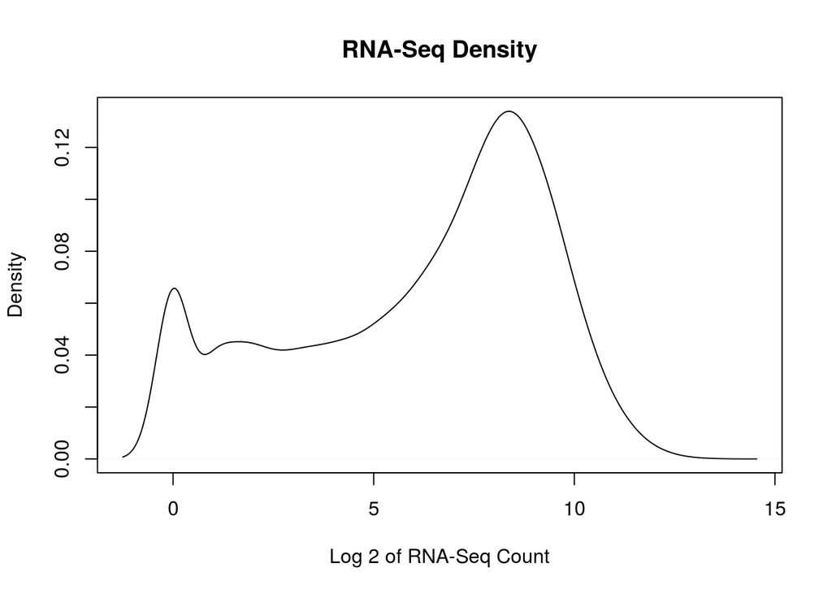

```r
# obtain the rnaseq and ribosomal occupancy of the CDS region
rnaseq_CDS <- get_rnaseq(ribo.object = original.ribo,
                         tidy        = TRUE,
                         alias       = TRUE,
                         region      = "CDS",
                         compact     = FALSE,
                         experiment  = "GSM1606108")


rc_CDS <- get_region_counts(ribo.object    = original.ribo,
                                tidy       = TRUE,
                                alias      = TRUE,
                                transcript = FALSE,
                                region     = "CDS",
                                compact    = FALSE,
                                experiment = "GSM1606108")

# filter out the lowly expressed transcripts
plot(density(log2(rnaseq_CDS$count)), xlab = "Log 2 of RNA-Seq Count", main = "RNA-Seq Density")
```

From the above plot, we decided to use a read count threshold of 2 for both the RNA-Seq and ribosome profiling region counts. We then plot the relationship between ribosome profiling and RNA-Seq counts.

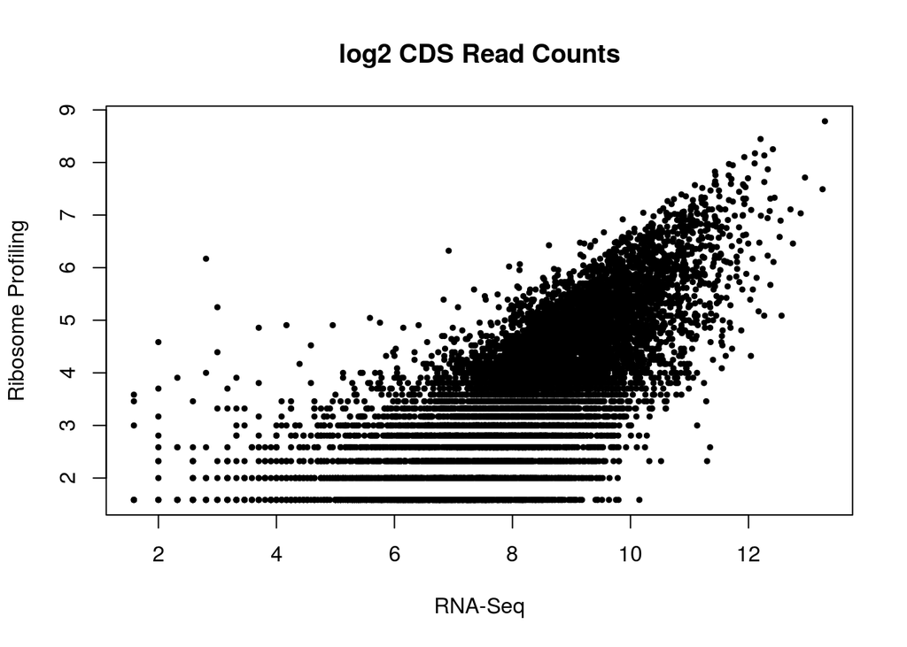

```r
# filter out transcripts with count value less than 2 for either ribosome profiling region counts or rnaseq
filtered_transcripts <- which(rnaseq_CDS$count > 2 & rc_CDS$count > 2)
rnaseq_CDS           <- rnaseq_CDS[filtered_transcripts, ]
rc_CDS               <- rc_CDS[filtered_transcripts, ]
plot(log2(rnaseq_CDS$count), log2(rc_CDS$count), xlab = "RNA-Seq", ylab = "Ribosome Profiling", main = "log2 CDS Read Counts", pch = 19, cex = 0.5)
```

Next, we calculate the ratio of ribosome profiling to RNA-Seq counts. This ratio has been used as a rough proxy for translational efficiency in the literature. We then visually inspect the distribution of this ratio.

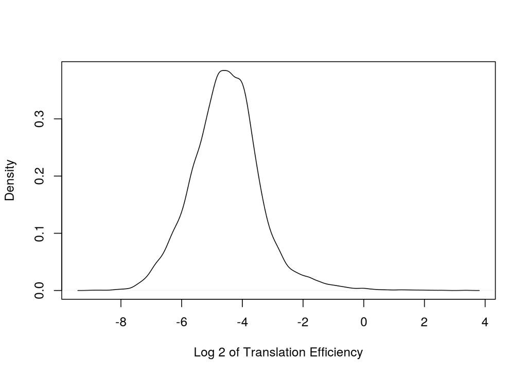

```r
# get the translational efficiency of CDS
te_CDS    <- rc_CDS$count/rnaseq_CDS$count
plot(density(log2(te_CDS)), xlab = "Log 2 of Translation Efficiency", main = "")
```

Using the above density distribution, we next select genes with a log2 ratio of greater than -2. From this threshold value, we identify 229 transcripts that exhibit relatively high translational efficiency.

```r
# filter for translational efficiency of the observed elbow at -2 (on the log2 scale, untransformed value of .25)
high_te <- rc_CDS$transcript[which(te_CDS > .25)]

# found 229 transcripts, first 20 shown here
head(high_te, n = 20)
```

```
#>  [1] "CPTP-201"     "FBXO6-201"    "ACTL8-201"    "SH3BGRL3-201" "TRNP1-201"
#>  [6] "IFI6-203"     "HEYL-201"     "COL9A2-202"   "HYI-201"      "CYP4X1-201"
#> [11] "FOXD2-201"    "CYR61-201"    "S1PR1-201"    "CSF1-201"     "TENT5C-201"
#> [16] "MLLT11-201"   "S100A11-201"  "SYT11-201"    "HSPA6-201"    "PLEKHA6-201"
```